# COVID-19 Cases Across Michigan

Paige Beffrey

January 07, 2022

## Introduction

The data throughout this report will provide you with knowledge on COVID-19 cases across the state of Michigan. A comparison can be made between COVID-19 and the different counties within the state of Michigan. Total deaths across the state and in each county they occurred in can also be identified as well as total number of cases. You will also be able to visualize trends by month and week for 3 specific counties in Michigan: Bay, Saginaw, and Midland counties.

## Data

The Michigan COVID-19 data for this document were obtained at https://www.michigan.gov/coronavirus/0,9753,7-406-98163_98173---,00.html in the Public Use Datasets called “Cases by County and Date”. The **December 29, 2021** dataset was used to create this report. Michigan county populations were found at https://worldpopulationreview.com/us-counties/states/mi which gives the 2018 census numbers. These were the most recent reliable numbers that I could find at the moment.

## Data munging

The Michigan COVID-19 dataset had a few peculiarities that needed to be dealt with in order to analyze it easily. There were several “counties” that are not actual Michigan counties that needed to be cleaned. The values for “Out-of-State” are not relevant for my purposes and were removed from the analyses. Likewise, prison populations (“FCI” and “MDOC”) cannot be ascribed to particular counties and were, therefore, also removed. Cases with “Unknown” origins were also removed. Finally, the dataset lists “City of Detroit” as a separate entity, those numbers were added back into it’s home country (Wayne) to facilitate analysis.

The number of cases and deaths per day are recorded for both confirmed and probable cases. To be as conservative as possible, these numbers were added together to create a total number of cases and deaths per day from each county (along with total cumulative cases and deaths). These total values, confirmed + probable, are used for all of the analyses in this report.

GIS information was left-joined onto the total data. The census data was also left-joined and used to create population-normalized values (cases or deaths per 100,000 population).

## Statewide distribution

The data found and plotted in figure 1, can provide you With information on cases and deaths across the state of Michigan. The first map, map A, demonstrates the amount of cases in the state of Michigan. One can easily look at the map and determine majority of cases were in the south eastern part of Michigan. The second map, map B, demonstrates the amount of deaths related to COVID in the state of Michigan. One can determine from this information that deaths are higher in the regions where cases are higher as well.

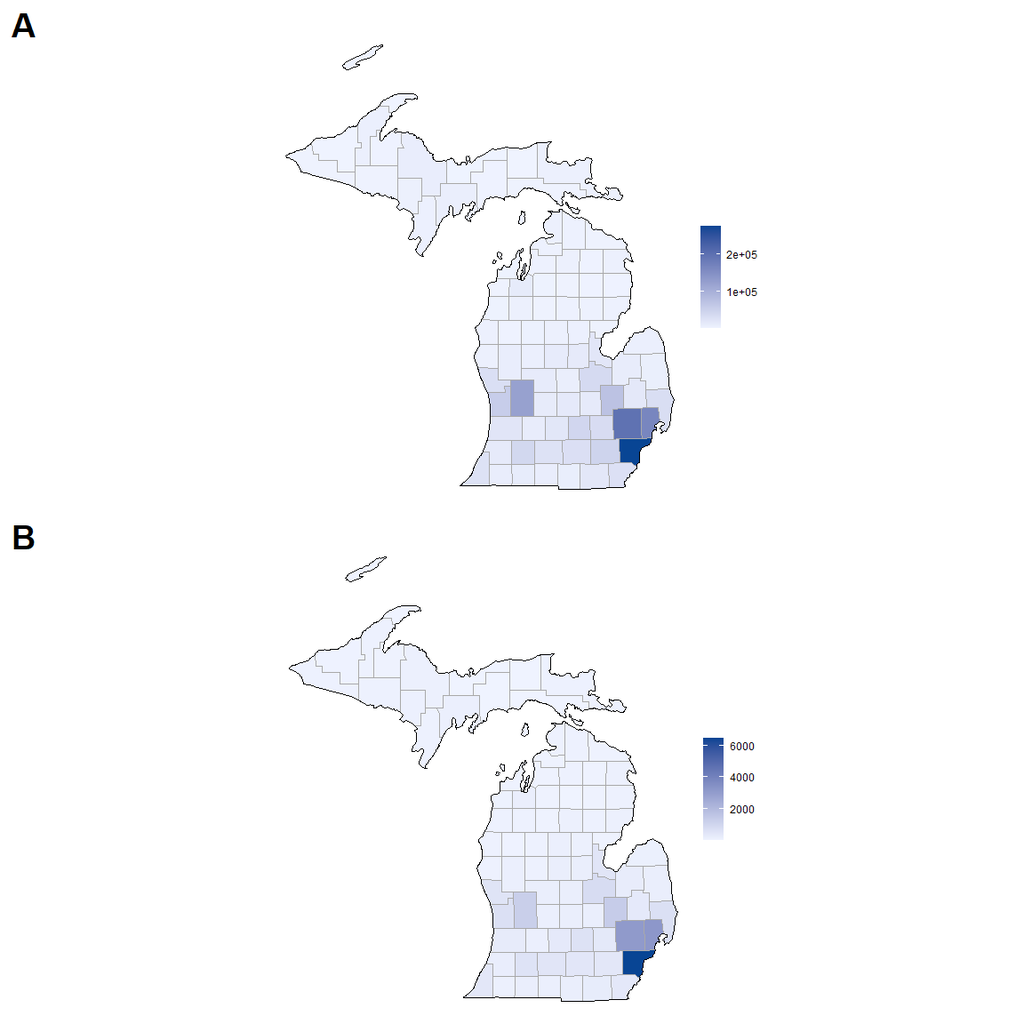

## State Overall Trends

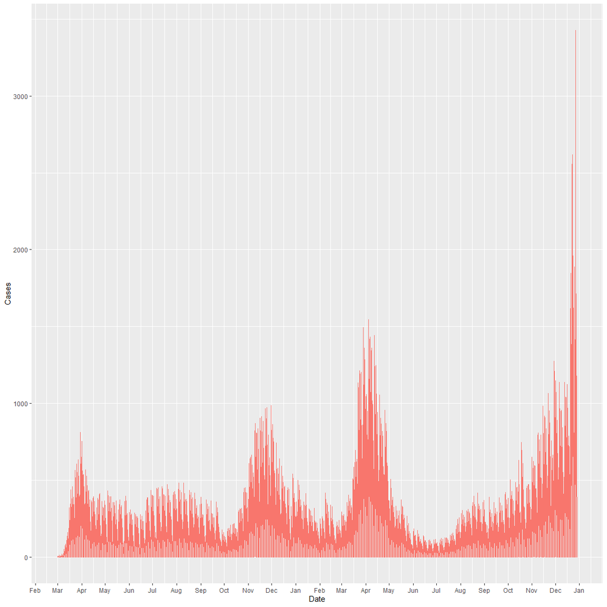

**Figure 2:** A comparison of the number of cases across the state of Michigan by month.

## Comparing Counties

Two graphs shown below show comparisons overtime for 3 specific counties. The counties included in the data set are Bay, Saginaw, and Midland counties. Figure 3 shows cases over a monthly period where as the figure 4 shows cases over a weekly period.

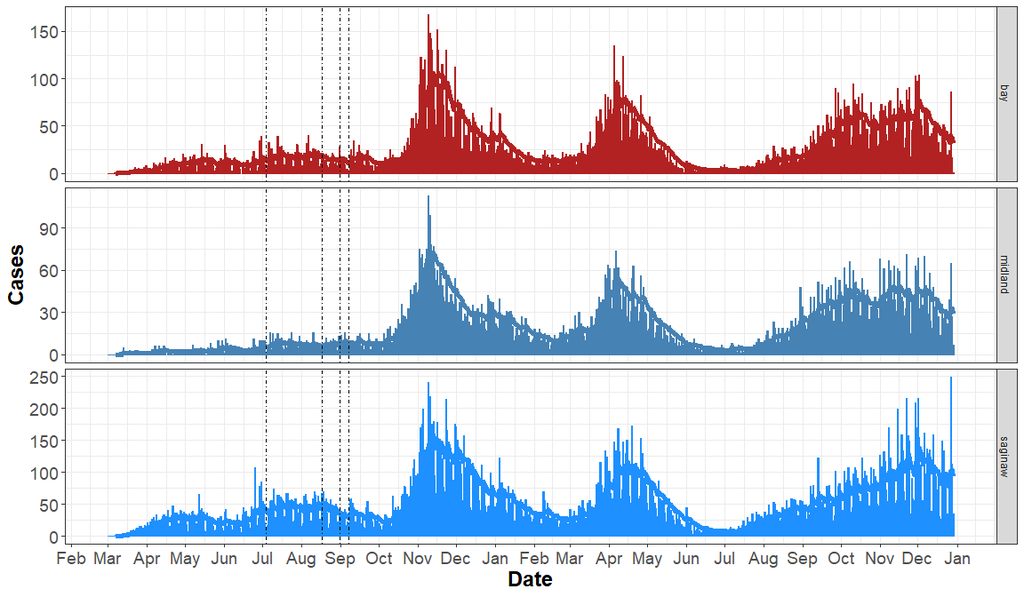

**Figure 3:** A comparison of the number of total cases in Bay, Saginaw, and Midland counties by month.

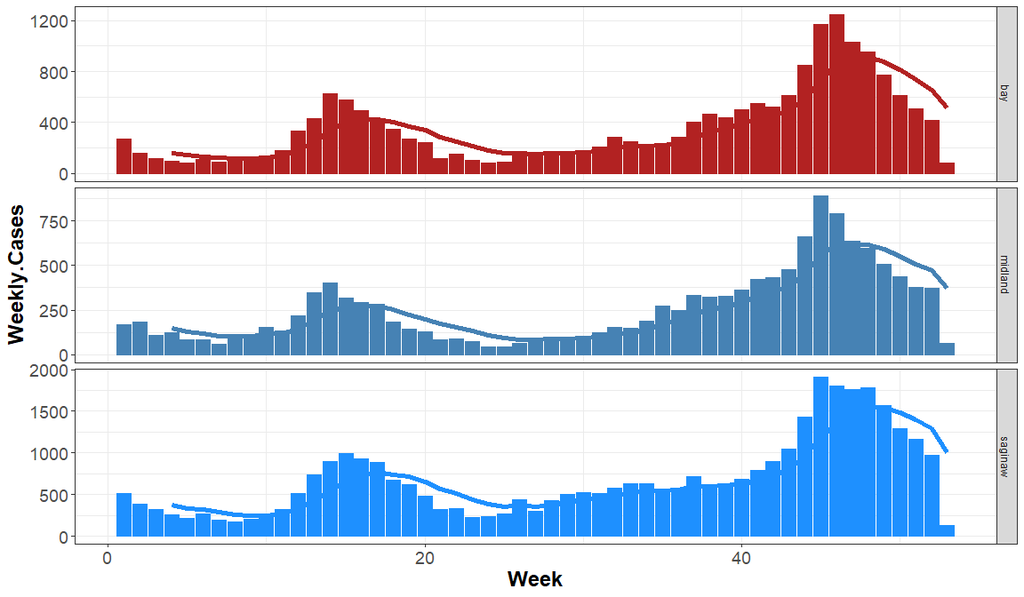

## Conclusions

In conclusion, COVID-19 can easily be split up into regions to be able to visualize how the state as a whole is being effected. It is important to notice that areas with higher populations of people tend to have more cases than those counties with lower populations. Knowing this information could help lead to ideas on how to better control the spread of COVID-19 throughout the state of Michigan.

## References

No additional refrences utilized.